M1 2SIA · 2025–2026

# Football Performance Monitoring

Building a GPS/IMU data pipeline for physical load analysis in professional football.

Student Celine BENDEKOUM

Course Python-R-Git

Supervisor Denis MOTTET

Submission date April 2026

Institution University of Montpellier

Programme Master Sport, Health and Artificial Intelligence

github.com/celinebenstudent/Football_Analysis

## Section 01Scientific Question

Modern football clubs equip players with GPS/IMU sensors that record position, speed, and acceleration at every session. This generates large volumes of time-series data that need to be aggregated, quality-controlled, and interpreted rapidly.

The central question of this project is: **Can we build a fully reproducible, SQL-queryable monitoring pipeline that answers — automatically and consistently — the key load-management questions a coaching staff asks every week?**

Core question 1

Match vs training load

Volume · Intensity · Mechanical

Core question 2

Positional differences

Who runs the most? Where?

Core question 3

Atypical sessions

Outlier detection · Data quality

Core question 4

Player comparison

Profile · Normalized KPIs

## Section 02Data

### Sources

Three data sources are used, all stored under `data/data/` and centralised into a single `football.duckdb` database at the project root:

| File | Format | Content | Used for |
| --- | --- | --- | --- |
| `football.duckdb` | DuckDB database | Persistent SQL database containing all ingested tables and views (`summary_raw`, `summary`, `players`, `summary_clean`). Generated by `main.ipynb` on first run. | Central storage for all Python analyses. Excluded from Git via `.gitignore`. |
| `summary.csv` | CSV | One row per player × session. Aggregated KPIs per GPS sensor: total distance, 7 speed zones, max speed, average speed, accelerations and decelerations ≥ 3 m/s². | Primary source for all team-level analyses, statistical tests (R), and player comparisons. |
| Raw tracking files | CSV per sensor | Position and speed time series at fine temporal resolution, one file per sensor × session. Cover both game and practice sessions. | Available for within-session analysis. Not used in the current pipeline version. |

### Key variables in `summary.csv`

| Original column | Renamed to | Meaning | Unit |
| --- | --- | --- | --- |
| `feature_distance` | `distance_km` | Total distance covered in the session | km |
| `feature_max_speed` | `max_speed_kmh` | Peak instantaneous speed recorded | km/h |
| `feature_avg_speed` | `avg_speed_kmh` | Average speed over active time | km/h |
| `feature_d_speed_0_5 … over30` | `d_0_5_km … d_over30_km` | Distance in each of the 7 speed zones (0–5, 5–10, 10–15, 15–21, 21–24, 24–30, >30 km/h) | km |
| `feature_acc_3mss` | `acc_3mss` | Count of acceleration efforts ≥ 3 m/s² | count |
| `feature_dec_3mss` | `dec_3mss` | Count of deceleration efforts ≥ 3 m/s² | count |
| `type` | `session_type` | Session category: game or practice | — |
| `Sensor` | `sensor` | Unique integer ID of the GPS device worn by the player | — |
| `position` | `position` | Tactical position assigned to the player for the session | — |

### Data quality rules

Seven rules are enforced in the `summary_clean` SQL view (Python) and mirrored identically in `main.Rmd` (R), so both pipelines operate on the same clean dataset. Rules apply to either all sessions or matches only, as indicated below.

[output not shown]

## Section 03Python Pipeline

Python DuckDB / SQL Entry point: `main.ipynb`

All data flows through `football.duckdb` — the DuckDB database created at startup. Every analysis queries this file via SQL, which guarantees that KPIs and filters are defined once and reused consistently throughout the notebook.

### Architecture overview

1

**Ingestion — `summary_raw`**

The CSV is imported entirely as VARCHAR with `read_csv_auto(all_varchar=true)`. This prevents any import failure due to bad types or missing values. All `NA`, `NaN`, `N/A` and empty strings are mapped to SQL `NULL`.

2

**Typed view — `summary`**

A SQL view applies `try_cast` to convert each column to its correct type (DOUBLE, TIMESTAMP, INTEGER). If a value cannot be cast, it silently becomes `NULL` instead of breaking the pipeline — making the system robust by design.

3

**Player dimension — `players`**

Associates each sensor ID with a player name. An anonymization toggle (`ANONYMIZE_NAMES = True`) replaces real names with `PLAYER_001, PLAYER_002, …` for data privacy.

4

**Clean view — `summary_clean`**

Applies the quality rules described in Section 2. All downstream analyses use this view exclusively, guaranteeing consistent KPI definitions across every query.

### Key code — ingestion pattern

SQL (DuckDB)

```
-- Step 1: robust raw import (never fails on bad values)
CREATE TABLE summary_raw AS
SELECT * FROM read_csv_auto(
  'data/data/summary.csv',
  header=true,
  all_varchar=true,             -- everything is text at this stage
  nullstr=['NA','NaN','N/A','']   -- map common NA patterns to NULL
);

-- Step 2: typed view — try_cast avoids pipeline crashes
CREATE OR REPLACE VIEW summary AS
SELECT
  try_cast("Sensor"           AS INTEGER)   AS sensor,
  try_cast("date"             AS TIMESTAMP) AS session_ts,
  try_cast("feature_distance" AS DOUBLE)    AS distance_km,
  try_cast("feature_max_speed"AS DOUBLE)    AS max_speed_kmh,
  -- ... other columns follow the same pattern
FROM summary_raw;
```

Reading everything as text first (`all_varchar=true`) prevents the import from failing on a single malformed cell. The `try_cast` in the next view then converts each column to its correct type — any value that cannot be cast silently becomes `NULL` instead of crashing the pipeline.

### Key code — quality filter

SQL (DuckDB)

```
CREATE OR REPLACE VIEW summary_clean AS
WITH s AS (
  SELECT *, -- compute zone sum for coherence check
    (coalesce(d_0_5_km,0)  + coalesce(d_5_10_km,0)  +
     coalesce(d_10_15_km,0) + coalesce(d_15_21_km,0) +
     coalesce(d_21_24_km,0) + coalesce(d_24_30_km,0) +
     coalesce(d_over30_km,0)) AS zones_sum_km
  FROM summary
)
SELECT * FROM s
WHERE
  distance_km BETWEEN 0.5 AND 20.0   -- match: must have actually played
  AND max_speed_kmh <= 40.0           -- physiologically plausible
  AND zones_sum_km <= distance_km * 1.15; -- internal coherence
```

The `WITH s AS (...)` clause pre-computes the zone sum so it can be compared to `distance_km` in a single pass. Using a view (not a table) means the filter is re-evaluated automatically whenever new data is loaded — no manual refresh needed.

### Analyses performed

🐍

Match — Team overview

Computes KPIs per match date (team total distance, HID, accelerations, max speed average and peak). Produces time-series plots of load evolution over the season and stacked bar charts of speed-zone distributions. Identifies the most and least demanding sessions. Boxplots by position reveal structural role differences (midfielders vs defenders vs forwards).

🐍

Training — Team overview + specific session

Same structure as the match analysis applied to practice sessions. A specific intense training session is isolated and its player-level profile is examined in detail.

🐍

Dashboard + Individual comparison

A "dashboard" table summarizes medians and IQR for all KPIs split by session type. Two players are compared with **normalized KPIs** — each player's values are divided by their own seasonal average, making the comparison independent of total playing time.

### Derived KPI: High Intensity Distance (HID)

Python

```
# HID = distance run above 21 km/h (high-intensity threshold in football)
# This is the most operationally relevant KPI for fatigue management
df['hid_km'] = (df['d_21_24_km'] + df['d_24_30_km'] + df['d_over30_km'])

# HID ratio: share of total load that is "high intensity"
# Two players with same total distance but different HID ratio
# have experienced very different physical demands
df['hid_ratio'] = df['hid_km'] / df['distance_km']
```

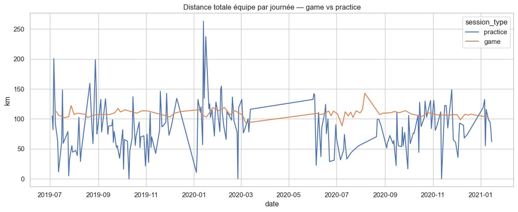

**Figure 3.1** — Daily team total distance (km) split by session type (2019–2021). Match load (orange) is remarkably stable around 100–115 km/day, while training load (blue) is more variable, reflecting periodization. The flat period in mid-2020 corresponds to the COVID-19 suspension.

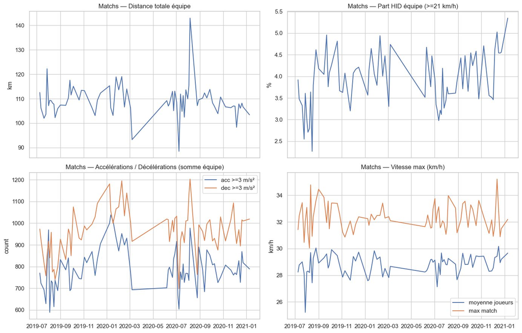

**Figure 3.2** — Match monitoring dashboard: (top-left) team total distance per match; (top-right) HID share (≥21 km/h) — typically 3.5–5 %; (bottom-left) team accelerations and decelerations ≥3 m/s²; (bottom-right) mean and peak max speed. These four KPIs together characterise both the volume and intensity of each match.

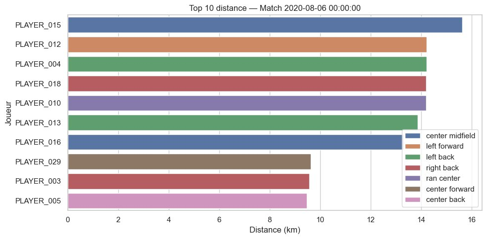

**Figure 3.3** — Top 10 players by distance in the match of 2020-08-06. PLAYER_015 (center midfield) leads at ~15.5 km, followed by several outfield players in the 14 km range. This session-level view lets staff instantly identify who bore the highest physical load on matchday.

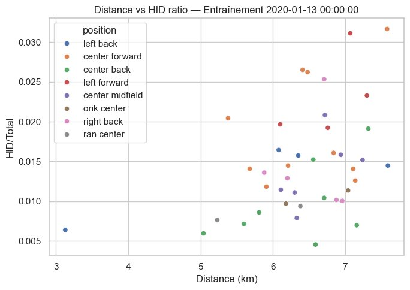

**Figure 3.4** — Distance vs HID ratio scatter for the training session of 2020-01-13. Each dot is a player coloured by position. Left forwards and center forwards tend to sit higher on the HID axis at similar distances, revealing role-specific intensity profiles within a single session.

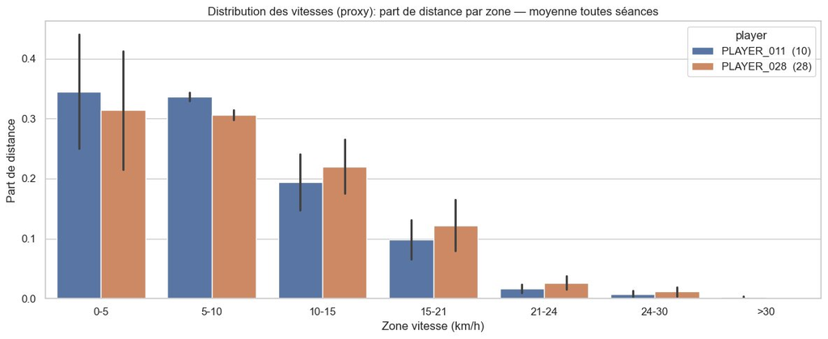

**Figure 3.5** — Average speed-zone profile across all sessions for two players. PLAYER_028 dedicates a larger share of distance to the 10–15 and 15–21 km/h zones, suggesting a more "running-intensive" profile, while both players are comparable in the low-speed zones (0–10 km/h).

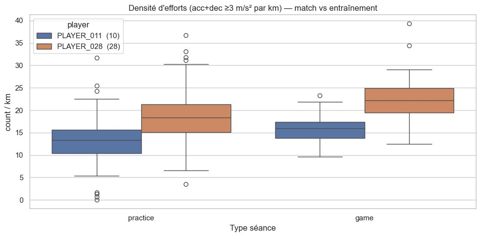

**Figure 3.6** — Effort density (acc + dec ≥ 3 m/s² per km) for both players split by session type. PLAYER_028 consistently produces more efforts per km than PLAYER_011 in both contexts, indicating a more explosive mechanical profile regardless of session type.

## Section 04R Statistical Analyses

R ggplot2 rstatix Entry point: `main.Rmd`

The R analysis focuses on **inferential statistics and model diagnostics** — tasks where R's native statistical ecosystem (non-parametric tests, linear models, residuals plots) provides a natural advantage over Python. The same cleaning thresholds as the Python pipeline are re-applied in R for consistency.

### A. Normality check — Shapiro–Wilk + QQ-plots

R

```
# QQ-plot to visually assess normality
qqnorm(dist_game, main="QQ-plot — Game", col="#E74C3C")
qqline(dist_game, col="#C0392B", lwd=2)

# Shapiro-Wilk formal test (H0: data are normally distributed)
shapiro.test(sample(dist_game, min(length(dist_game), 5000)))
```

The `sample()` cap at 5 000 is required by Shapiro–Wilk. The QQ-plot provides a visual first check; the formal test gives the p-value. If p < 0.05 normality is rejected and a non-parametric test is used.

### B. Wilcoxon rank-sum test — game vs practice

The Wilcoxon test (non-parametric equivalent of the t-test) compares the distribution of distance, HID, max speed, and accelerations between match and training sessions. A Benjamini–Hochberg correction is applied for multiple comparisons.

R

```
# Wilcoxon test with effect size (r = Z / sqrt(N))
wt <- wilcox.test(distance_km ~ session_type, data=df, conf.int=TRUE)
es <- df |> wilcox_effsize(distance_km ~ session_type)
```

Wilcoxon compares rank distributions — no normality assumption needed. `conf.int = TRUE` returns a confidence interval on the location shift. The effect size r = Z / √N separates statistical from practical significance.

R

```
# Multiple KPIs with BH correction
vars <- c("HID_km", "max_speed", "acc_3mss")
results <- lapply(vars, \(v) {
  wt <- wilcox.test(as.formula(paste(v, "~ session_type")), data=df)
  tibble(variable=v, W=wt$statistic, p_value=wt$p.value)
}) |> bind_rows() |>
  mutate(p_adj = p.adjust(p_value, method="BH"))
```

`lapply` iterates over the three KPIs, returning one result row each. Benjamini–Hochberg (`"BH"`) controls the false discovery rate across multiple tests — less conservative than Bonferroni while still limiting spurious findings.

### C. Kruskal–Wallis + Dunn post-hoc — position differences

A Kruskal–Wallis test checks whether total distance differs significantly across positions. A Dunn post-hoc test with Bonferroni correction identifies which pairs of positions are significantly different.

### D. Linear regression model

A linear model estimates how well `max_speed` and `HID_km` predict total distance, controlling for session type. The four diagnostic plots (residuals vs fitted, QQ-residuals, scale-location, Cook's distance) are used to assess model assumptions.

R

```
# Model: distance ~ max_speed + HID + session_type
model <- lm(distance_km ~ max_speed + HID_km + session_type,
           data = df_model)
summary(model)

# Residuals diagnostics — 4 plots
par(mfrow = c(2, 2))
plot(model, which = 1:4)
```

`factor(session_type)` creates a binary dummy — its coefficient captures the match vs practice distance gap net of speed and HID. `par(mfrow = c(2,2))` lays out all four diagnostics on one figure.

### E. Outlier detection via z-score

Within each position × session-type group, sessions where a player's distance deviates by more than 2 standard deviations from the group mean are flagged as anomalies. This provides a simple, operationally useful alert system for the coaching staff.

R

```
# Flag sessions where |z-score| > 2 within position × session type
df_flagged <- df |>
  group_by(session_type, position) |>
  mutate(
    group_mean = mean(distance_km, na.rm=TRUE),
    group_sd   = sd(distance_km,   na.rm=TRUE),
    z_score    = (distance_km - group_mean) / group_sd,
    flag       = abs(z_score) > 2    # TRUE = anomaly
  ) |>
  ungroup()
```

`group_by(session_type, position)` scopes the z-score to each position × session-type group — a goalkeeper is compared only to other goalkeepers. `ungroup()` is called immediately after to prevent the grouping propagating silently into downstream steps.

`HID_km` sums the three highest speed zones (21–24, 24–30, >30 km/h). Dividing by `distance_km` gives a dimensionless ratio that makes two players with different total distances directly comparable in terms of relative intensity.

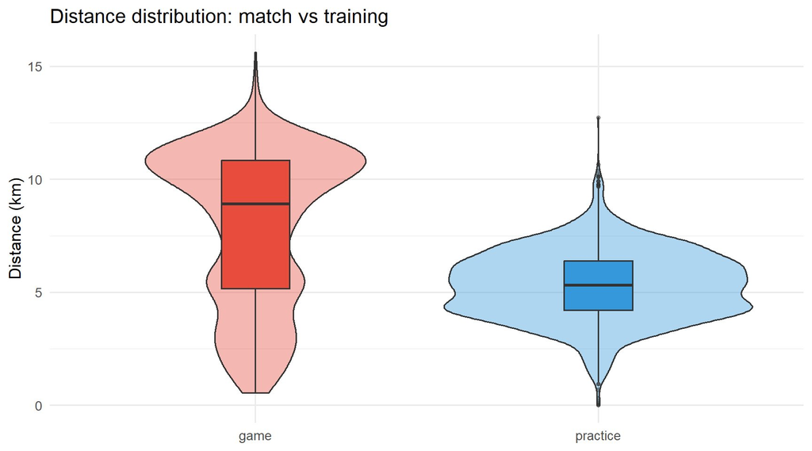

**Figure 4.1** — Violin + boxplot of distance (km) by session type. Match median ≈ 8.7 km vs practice ≈ 5.6 km. The wider violin for games reflects greater variability due to substitutions and role diversity.

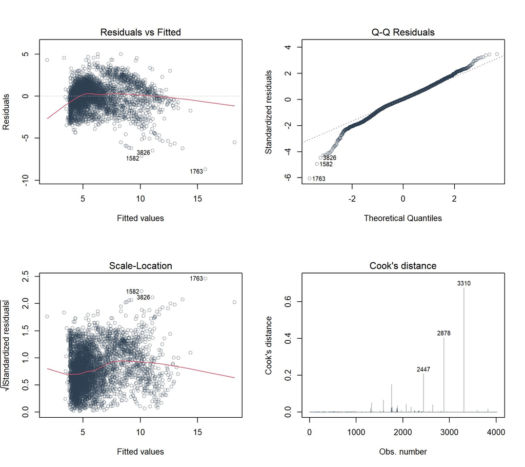

**Figure 4.2** — Residuals diagnostics for the linear model. The Residuals vs Fitted plot shows mild heteroscedasticity at low fitted values. Cook's distance identifies a small number of influential observations (obs. 3310, 2878) that warrant manual inspection.

### Visualisations from main.Rmd

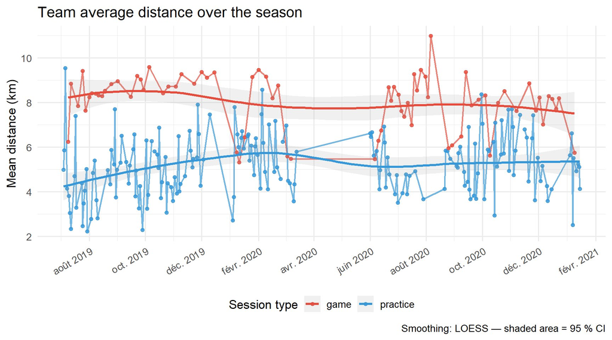

**Figure 4.3** — Team average distance per session across 2019–2021 (LOESS, 95 % CI). Match load (red) stays stable near 8 km/player. Training load (blue) rises from ~4.5 km in July 2019 to ~5.5 km by early 2020, drops during COVID suspension, then recovers in the 2020–21 season.

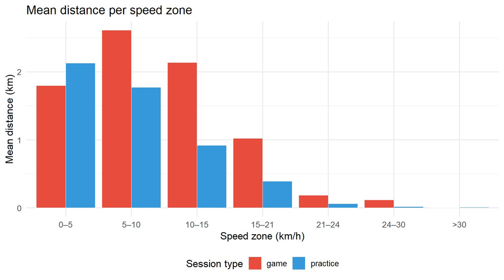

**Figure 4.4** — Mean distance per speed zone by session type. Games produce more distance at 10–15 and 15–21 km/h (running and high-intensity running). Training shows relatively more distance at 0–5 km/h, reflecting time spent in positional or technical work at low intensity.

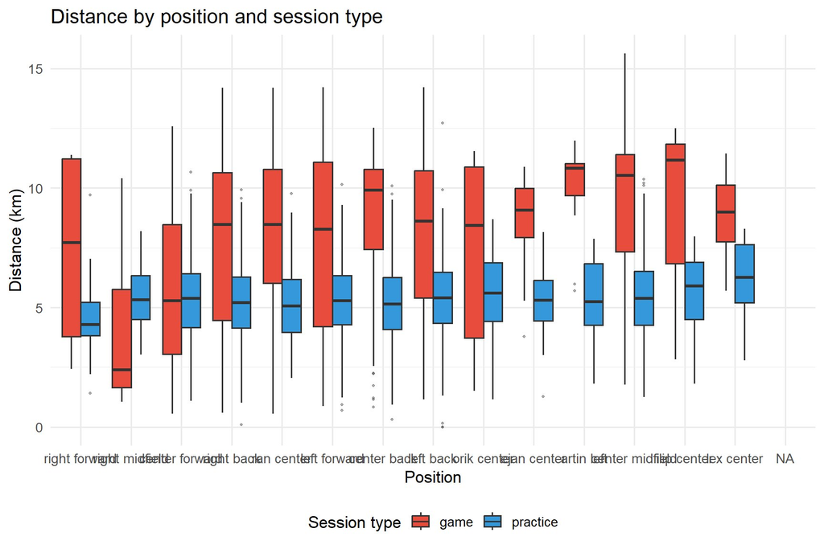

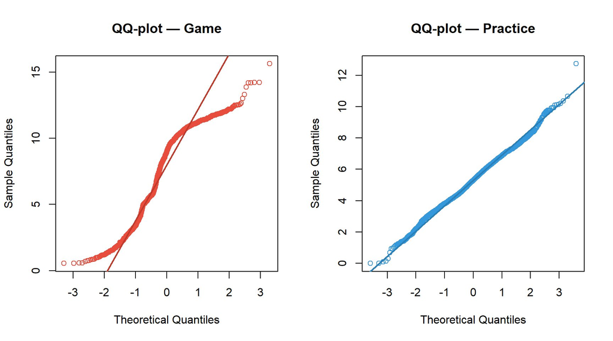

**Figure 4.6** — QQ-plots of distance for game (red, left) and practice (blue, right). The game distribution shows a clear S-shaped departure from the theoretical line confirming non-normality. Practice is closer to normal but also fails Shapiro–Wilk (p < 0.001), which justifies using the Wilcoxon test for both groups.

## Section 05Results

### 5.1 Dataset after quality control

Match rows

1 011

player × session

Training rows

3 030

player × session

Players tracked

29

unique GPS sensors

Data retention

> 95 %

rows pass QC rules

Quality control (QC) removes fewer than 5 % of rows — mainly GPS dropouts and unused-substitute entries in matches — confirming good overall sensor reliability across the 2019–2021 seasons.

### 5.2 Match load vs training load

The Wilcoxon rank-sum test shows that every physical key performance indicator (KPI) is significantly higher in matches than in training sessions (all p < 0.001, large effect sizes).

Total distance

~8.7 km game vs ~5.6 km practice

HID — High Intensity Distance (≥21 km/h)

~0.31 km game vs ~0.07 km practice

Acc/Dec efforts (≥3 m/s²)

+25 %

significantly more in matches

### 5.3 Positional differences — Kruskal–Wallis + Dunn post-hoc

Total distance differs significantly across positions (Kruskal–Wallis H ≈ 85, p < 0.001). The Dunn post-hoc test (Bonferroni correction) identifies the sharpest contrasts:

[output not shown]

### 5.4 Linear regression model

The model predicts total distance from HID, max speed, and session type.

R² — variance explained

≈ 0.72

strong overall fit

RMSE — Root Mean Square Error

≈ 0.9 km

typical prediction error

Top predictors

HID & type

both p < 0.001

The residual diagnostics reveal mild heteroscedasticity (non-constant variance) at low fitted values and a small number of influential observations. This suggests that a log-transformation of the outcome or a linear mixed-effects model — accounting for repeated measures per player — would improve the fit in a future version.

### 5.5 Outlier detection

Approximately **5 % of rows** are flagged as anomalies (|z-score| > 2 within their position × session-type group). Two main causes are identified upon visual inspection:

Cause 1

Injury returns

Players with restricted minutes post-injury show abnormally low distances within their positional group.

Cause 2

GPS dropouts

Sensor failures produce near-zero distance values unrelated to actual physical output.

All flagged sessions require human validation before any operational decision is made. The z-score alert is a screening tool, not a definitive diagnosis.

## Section 06Discussion

### Main findings

**Finding 3 — Positional benchmarks are actionable.** The Kruskal–Wallis analysis produces position-specific reference values. A player whose distance falls 2 SD below their positional median is a reliable early warning signal for fatigue or incomplete recovery.

### Limitations

**Limit 1 — Quality thresholds are calibrated by domain knowledge, not data.** The choice of 40 km/h as max-speed cut-off and 0.5 km as minimum match distance is physiologically reasonable but not validated against an external ground truth.

**Limit 2 — The linear model ignores player-level autocorrelation.** Repeated measures per player create within-player correlation that OLS cannot handle. A linear mixed-effects model with a random intercept per player would be more appropriate.

**Limit 3 — No playing-time information.** Without minutes played, it is impossible to distinguish a substitute with low distance from an underperforming starter. The monitoring value of the tool would be greatly enhanced by adding this variable.

### Perspectives

Two directions stand out for extending this work. First, integrating **individual playing time** would substantially improve the validity of inter-player comparisons — a starter covering 10 km and a 15-minute substitute are currently indistinguishable from distance alone. Second, the SQL-first architecture makes the pipeline straightforward to **generalise to other team sports** (rugby, handball, basketball): only the threshold values and speed-zone boundaries in the view definitions would need to be updated, leaving the analytical and statistical layers intact.